# Project:

Michil Trofimov, Vlada Tuliavko, Ustin Zolotikov

2023-01-16

## Dependencies

Libraries that we have used. Data.table, dlookr, flextable were not reviewed in our lecture.

```r
library(data.table)
library(ggplot2)
library(dplyr)
library(dlookr)
library(flextable)
```

## Pre-process

Let’s look at our data with a function `diagnose` from a package *dlookr*

| variables | types | missing_count | missing_percent | unique_count | unique_rate |
| --- | --- | --- | --- | --- | --- |
| instant | integer | 0 | 0.0000000 | 731 | 1.000000000 |
| dteday | IDate | 0 | 0.0000000 | 731 | 1.000000000 |
| season | integer | 0 | 0.0000000 | 4 | 0.005471956 |
| yr | integer | 0 | 0.0000000 | 2 | 0.002735978 |
| mnth | integer | 0 | 0.0000000 | 12 | 0.016415869 |
| holiday | integer | 0 | 0.0000000 | 2 | 0.002735978 |
| weekday | integer | 0 | 0.0000000 | 7 | 0.009575923 |
| workingday | integer | 0 | 0.0000000 | 2 | 0.002735978 |
| weathersit | integer | 0 | 0.0000000 | 3 | 0.004103967 |
| temp | numeric | 2 | 0.2735978 | 499 | 0.682626539 |
| atemp | numeric | 0 | 0.0000000 | 690 | 0.943912449 |
| hum | numeric | 5 | 0.6839945 | 592 | 0.809849521 |
| windspeed | numeric | 1 | 0.1367989 | 650 | 0.889192886 |
| casual | integer | 0 | 0.0000000 | 606 | 0.829001368 |
| registered | integer | 1 | 0.1367989 | 679 | 0.928864569 |
| cnt | integer | 0 | 0.0000000 | 696 | 0.952120383 |

We need to factories data related to the date (season, yr, mnth, holiday, weekday, workingday) and variable weathersit (type of weather).

There are missing values in columns temp, hum, windspeed and registered. Considering that each value corresponds to a day of a year, we would not like to drop rows with missing values.

Let’s fill missing values:

- temp: we will take values from column atemp
- hum: we will fill with an average value of humidity in a corresponding month
- windspeed: the same as hum
- registered: we find value by counting cnt - casual

Now we need to find outliers

| variables | outliers_cnt | outliers_ratio | outliers_mean | with_mean | without_mean |
| --- | --- | --- | --- | --- | --- |
| instant | 0 | 0.0000000 |  | 366.0000000 | 366.0000000 |
| temp | 0 | 0.0000000 |  | 0.4953478 | 0.4953478 |
| atemp | 0 | 0.0000000 |  | 0.4743540 | 0.4743540 |
| hum | 2 | 0.2735978 | 0.0939585 | 0.6277220 | 0.6291864 |
| windspeed | 13 | 1.7783858 | 0.4166235 | 0.1904919 | 0.1863976 |
| casual | 44 | 6.0191518 | 2,661.9545455 | 848.1764706 | 732.0101892 |
| registered | 0 | 0.0000000 |  | 3,656.1723666 | 3,656.1723666 |
| cnt | 0 | 0.0000000 |  | 4,504.3488372 | 4,504.3488372 |

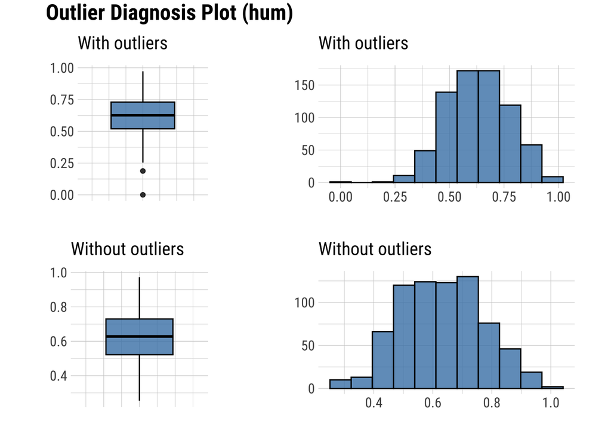

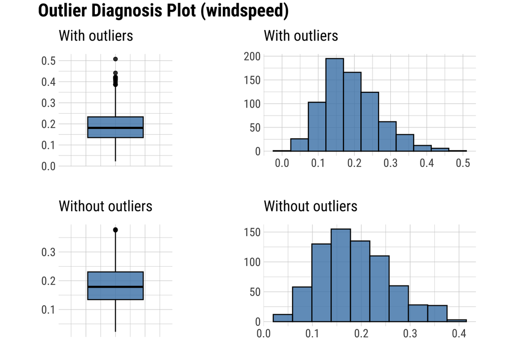

There is a weird outlier for humidity with value 0. Remove it.

## Correlation plot

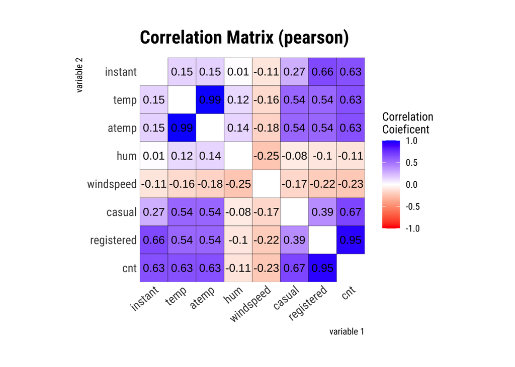

```r
df_clean %>%
  correlate() %>%
  plot()
```

## Statistical analysis

### Linear regression

It would be interesting to check correlation between temp and number of users.

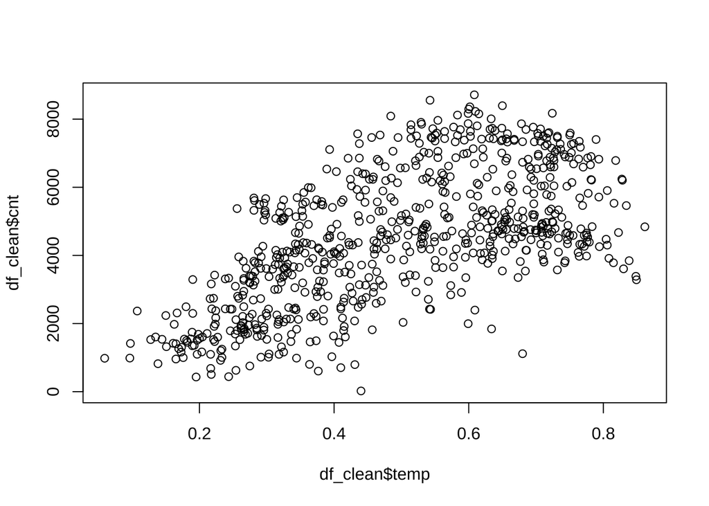

Does not look obvious. Let’s fit linear regression number of users ~ temperature

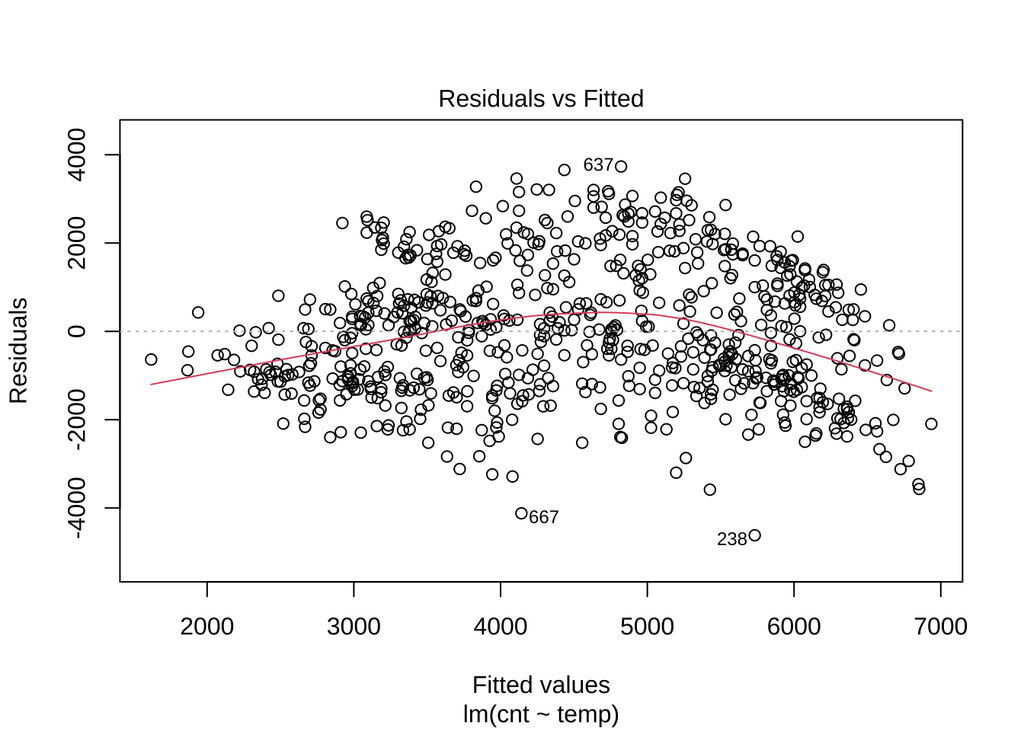

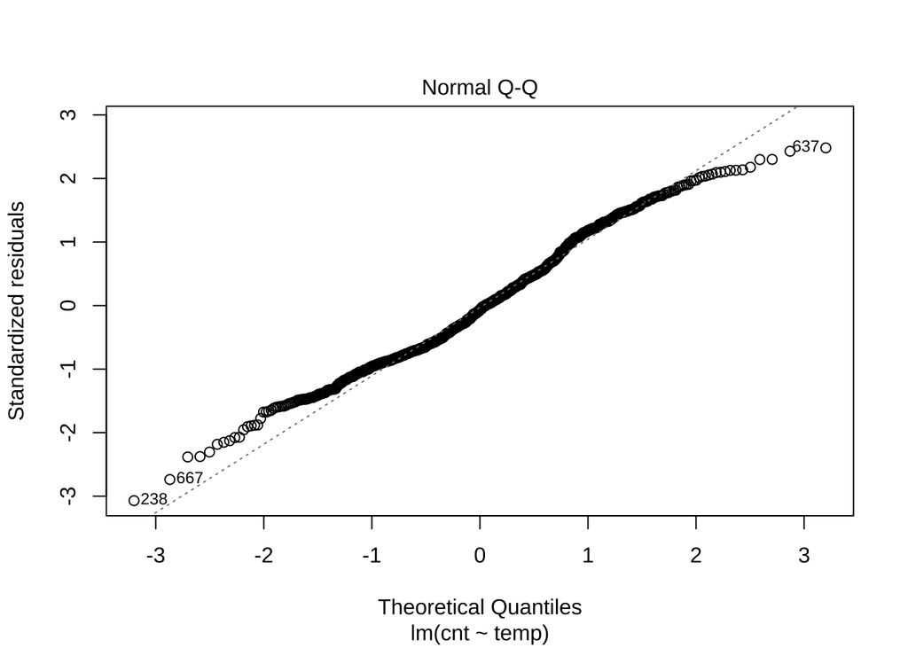

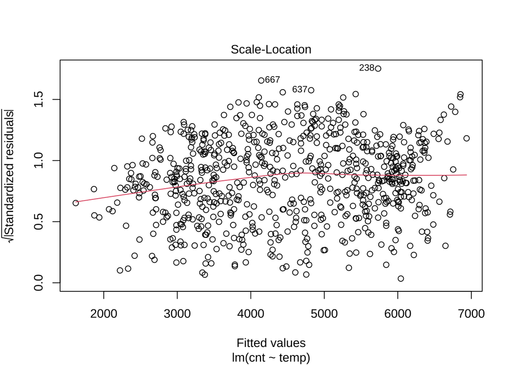

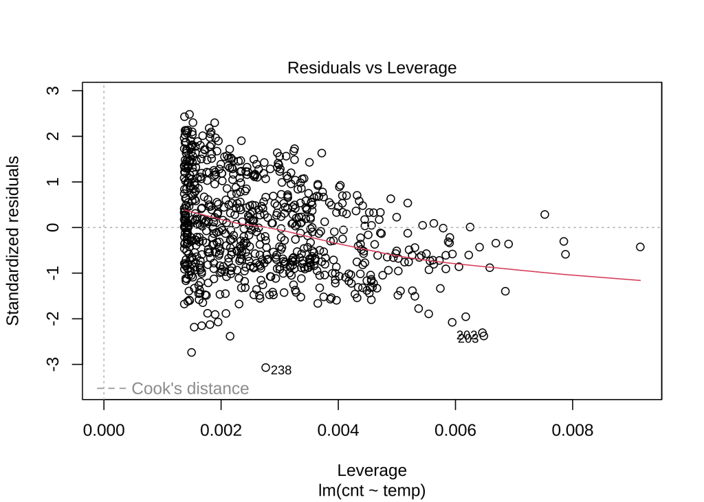

```
##
## Call:
## lm(formula = cnt ~ temp, data = df_clean)
##
## Residuals:
##     Min      1Q  Median      3Q     Max
## -4617.1 -1136.6  -100.8  1045.9  3733.9
##
## Coefficients:
##             Estimate Std. Error t value Pr(>|t|)
## (Intercept)   1226.9      160.8   7.629 7.44e-14 ***
## temp          6625.2      304.5  21.759  < 2e-16 ***
## ---
## Signif. codes:  0 '***' 0.001 '**' 0.01 '*' 0.05 '.' 0.1 ' ' 1
##
## Residual standard error: 1506 on 728 degrees of freedom
## Multiple R-squared:  0.3941, Adjusted R-squared:  0.3932
## F-statistic: 473.5 on 1 and 728 DF,  p-value: < 2.2e-16
```

There is very significant p-value < 2e-16, which indicates that there is a linear relationship between response variable (number of users) and predict variable (temperature)

### T-test

It would be interesting to see, whether day is a holiday or not influeneces number of users

```
##
##  Welch Two Sample t-test
##
## data:  holiday_no$cnt and holiday_yes$cnt
## t = 1.7166, df = 21.004, p-value = 0.1008
## alternative hypothesis: true difference in means is not equal to 0
## 95 percent confidence interval:
##  -168.6624 1763.8839
## sample estimates:
## mean of x mean of y
##  4532.611  3735.000
```

There is no significant association (p-value > 0.05) between holiday and number of users.

Perhaps, the problem is in the size of samples. We have only 21 holiday days.

Let’s check whether its a working day or not, influence number of users.

```
##
##  Welch Two Sample t-test
##
## data:  weekdays$cnt and weekends$cnt
## t = 1.6524, df = 413, p-value = 0.0992
## alternative hypothesis: true difference in means is not equal to 0
## 95 percent confidence interval:
##  -49.78395 574.96533
## sample estimates:
## mean of x mean of y
##  4592.760  4330.169
```

Let’s look at number of unregistered users

```
##
##  Welch Two Sample t-test
##
## data:  weekdays$casual and weekends$casual
## t = -12.713, df = 273.62, p-value < 2.2e-16
## alternative hypothesis: true difference in means is not equal to 0
## 95 percent confidence interval:
##  -881.6636 -645.2180
## sample estimates:
## mean of x mean of y
##  607.6934 1371.1342
```

Yes, there is significant association between working day or not and number of casual users

### Chi-squared

```
##
##  Pearson's Chi-squared test
##
## data:  table(df_clean$weathersit, df_clean$mnth)
## X-squared = 39.831, df = 22, p-value = 0.01131
```

P-value < 0.05, however, results may be inaccurate. Becase, expected frequencies for weathersit == 3 are less than 5.